# Network Intrusion Detection System

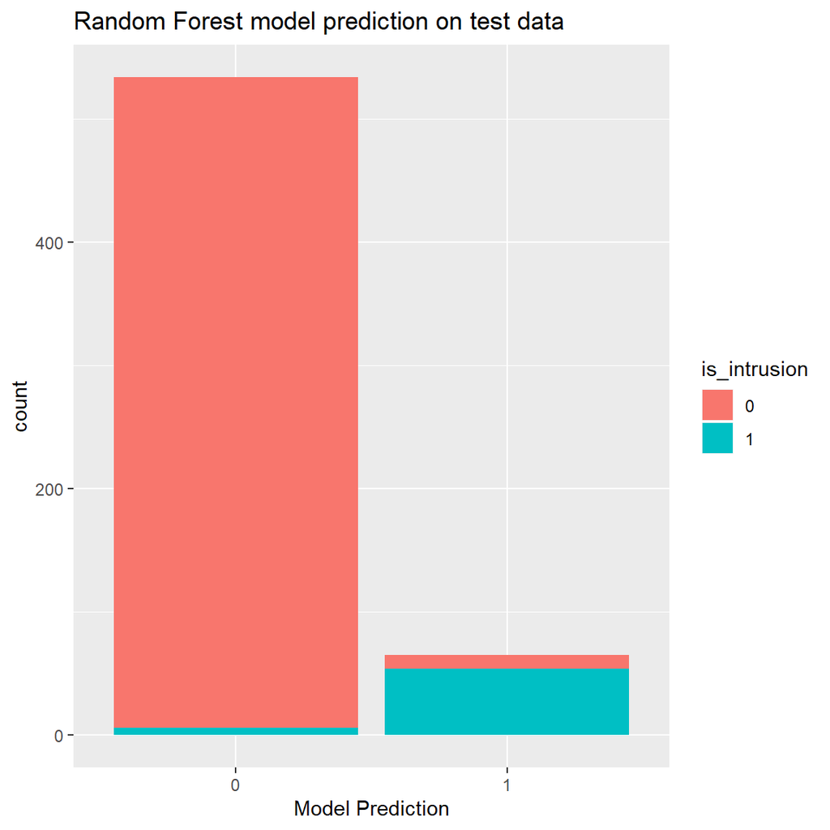

```r
ggplot(data = network.test, aes(x = pred.rf.test, fill = is_intrusion)) +geom_histogram(stat = "count") + labs(x = "Model Prediction", title = "Random Forest model prediction on test data")
```

**Two measures of variable importance are reported**

```r
importance(rf.network)
```

```
##                            0         1 MeanDecreaseAccuracy
## duration           19.260033 24.677654            23.427724
## protocol_type       5.465634  4.541382             7.071839
## service            12.006008 28.240195            23.494089
## flag               24.681112 29.817941            34.073569
## src_bytes          11.518864 27.020447            22.813335
## dst_bytes           9.929364 16.578274            16.758737
## hot                 7.255863  9.200391            10.216728
## logged_in           4.444841 16.986646             9.360669
## num_compromised     0.000000  0.000000             0.000000
## root_shell          0.000000  0.000000             0.000000
## num_root           -1.417028  2.007504             1.004711
## num_file_creations  0.000000  0.000000             0.000000
## num_shells          0.000000  0.000000             0.000000
## num_access_files    0.000000  0.000000             0.000000
## is_guest_login      5.909748  9.928293             9.714957
##                    MeanDecreaseGini
## duration             48.49153177637
## protocol_type         6.20502745290
## service              73.74283251071
## flag                 75.15083370121
## src_bytes            77.23996424552
## dst_bytes            27.73700131255
## hot                   6.45905244466
## logged_in            12.77928113111
## num_compromised       0.02362951270
## root_shell            0.00000000000
## num_root              0.19187263799
## num_file_creations    0.00371887654
## num_shells            0.00000000000
## num_access_files      0.00005133986
## is_guest_login        5.33887861307
```

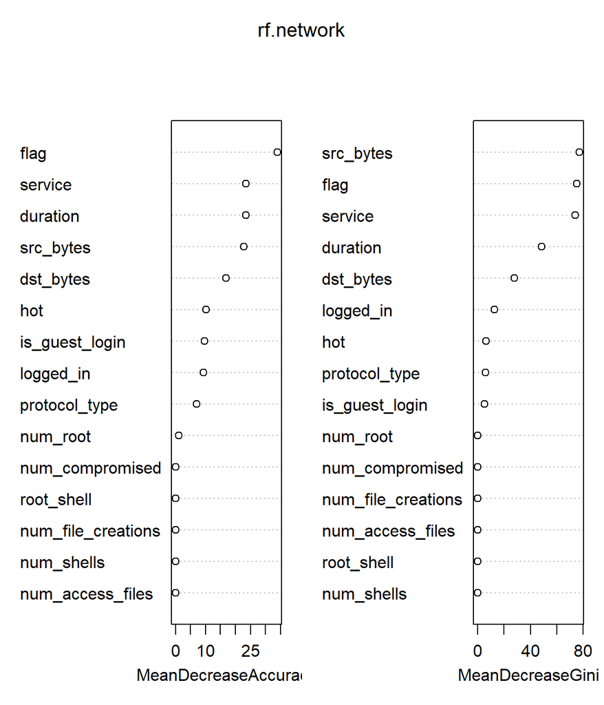

```r
varImpPlot(rf.network)
```

-The former is based upon the mean decrease of accuracy in predictions on the out of bag samples when a given variable is excluded from the model. The latter is a measure of the total decrease in node impurity that results from splits over that variable, averaged over all trees.

-The results indicate that across all of the trees considered in the random forest, flag, service, duration, src_bytes and dst-bytes are the most important variables.

## Gradient Boosting Machine

> GBMs build an ensemble of shallow and weak successive trees with each tree learning and improving on the previous. When combined, these many weak successive trees produce a powerful “committee” for prediction and classification.

> GBMs are popular given they are often difficult to beat on accuracy. Further, they are highly flexible (several parameters can be tuned) and do not require data pre-processing to create powerful classification models.

> Since tuning many parameters can be computationally expensive, this model has been implemented with stochastic (random) grid search. This reduces training time and usually has little impact on accuracy.

> For analysis of the strength of GBM models in network anomaly detection, see “An in-depth experimental study of anomaly detection using gradient boosted machine.” (Tama and Rhee, 2017)

> For details on documentation and guides used to enable this analysis, see:
- http://docs.h2o.ai/h2o/latest-stable/h2o-docs/data-science/gbm.html
- https://github.com/h2oai/h2o-3/blob/master/h2o-docs/src/product/tutorials/gbm/gbmTuning.Rmd
- http://uc-r.github.io/gbm_regression

```r
## The GBM will be performed using the h2o package
## This package requires data an h2o object (h2o frame, not a data frame)

# Split above training set once more to include small validation set for h2o gbm fitting (using cv in tuning is comp. expensive in h2o)
set.seed(45)
valid.index <- createDataPartition(network.train$is_intrusion, p = .75,
                                  list = FALSE,
                                  times = 1)
valid.train <- network.train[valid.index,]
valid.test <- network.train[-valid.index,]

# Convert data sets to H2O objects
network.h2o <- as.h2o(network)
h2o.train <- as.h2o(network.train)
h2o.test <- as.h2o(network.test)
train <- as.h2o(valid.train)
valid <- as.h2o(valid.test)
# Response for the supervised problem
response <- "is_intrusion"

# Use all other columns (except for the name) as predictors
predictors <- setdiff(names(network.h2o), c(response, "name"))

# Split above training set once more to include small validation set for h2o gbm fitting purposes (cv within tuning search computationally expensive)
split <- h2o.splitFrame(h2o.train, ratios = 0.75)
train <- split[[1]]
valid <- split[[2]]
```

**Establish baseline performance including 5-fold cv**

```r
# Baseline model
gbm.base <- h2o.gbm(x = predictors, y = response, training_frame = h2o.train, nfolds = 5)
# Get summary
gbm.base
```

```
## Model Details:
## ==============
##
## H2OBinomialModel: gbm
## Model ID:  GBM_model_R_1589500959158_4328
## Model Summary:
##   number_of_trees number_of_internal_trees model_size_in_bytes min_depth
## 1              50                       50                9685         5
##   max_depth mean_depth min_leaves max_leaves mean_leaves
## 1         5    5.00000          6         17    10.80000
##
##
## H2OBinomialMetrics: gbm
## ** Reported on training data. **
##
## MSE:  0.01655684
## RMSE:  0.1286734
## LogLoss:  0.04901129
## Mean Per-Class Error:  0.01712963
## AUC:  0.9957832
## AUCPR:  0.9636098
## Gini:  0.9915664
## R^2:  0.8160351
##
## Confusion Matrix (vertical: actual; across: predicted) for F1-optimal threshold:
##           0   1    Error      Rate
## 0      2104  56 0.025926  =56/2160
## 1         2 238 0.008333    =2/240
## Totals 2106 294 0.024167  =58/2400
##
## Maximum Metrics: Maximum metrics at their respective thresholds
##                         metric threshold       value idx
## 1                       max f1  0.504667    0.891386   9
## 2                       max f2  0.504667    0.948963   9
## 3                 max f0point5  0.504818    0.916667   8
## 4                 max accuracy  0.504667    0.975833   9
## 5                max precision  0.994714    1.000000   0
## 6                   max recall  0.217961    1.000000  11
## 7              max specificity  0.994714    1.000000   0
## 8             max absolute_mcc  0.504667    0.883670   9
```

[output cut: 68 more lines]

```
## ---
##                   mean           sd cv_1_valid cv_2_valid cv_3_valid
## pr_auc      0.95173556  0.026594283  0.9551412 0.96564126 0.95639306
## precision   0.77623963   0.07477625  0.8194444 0.76785713  0.7605634
## r2          0.78997624  0.061853506 0.81955624 0.82085043  0.8180903
## recall      0.99259007 0.0101493895        1.0        1.0  0.9818182
## rmse        0.13389209  0.008004953 0.13824183 0.11997819 0.13439555
## specificity 0.96963805 0.0068984376  0.9698376  0.9707865  0.9610984
##             cv_4_valid cv_5_valid
## pr_auc         0.97511  0.9063924
## precision    0.8666667  0.6666667
## r2           0.8118836 0.67950046
## recall       0.9811321        1.0
## rmse        0.13954017 0.13730471
## specificity  0.9799499 0.96651787
```

**Model tuning**

- Implement random search over large grid to find near-optimal results

```r
# Search criteria with stopping metrics:
# stops the grid search if none of the last 10 models have managed to have a 0.5% improvement in chosen metric
# compared to the best model before that. If we continue to find improvements then I cut the grid search off
# after 3600 seconds (60 minutes).

search_criteria <- list(
  strategy = "RandomDiscrete",
  stopping_metric = "AUC",
  stopping_tolerance = 0.005,
  stopping_rounds = 10,
  max_runtime_secs = 60*60,
  max_models = 100
  )

# Fuller hyperparameter search
hyper_params = list(
  ## depth 10+ usually not necessary and risks overfit
  max_depth = seq(1,9,1),

  ## search a large space of row sampling rates per tree
  sample_rate = seq(0.2,1,0.01),

  ## search a large space of column sampling rates per split
  col_sample_rate = seq(0.2,1,0.01),

  ## search a large space of column sampling rates per tree
  col_sample_rate_per_tree = seq(0.2,1,0.01),

  ## search a large space of the number of min rows in a terminal node
  min_rows = 2^seq(0,log2(nrow(train))-1,1),

  ## try all histogram types (QuantilesGlobal and RoundRobin are good for numeric columns with outliers)
  histogram_type = c("UniformAdaptive","QuantilesGlobal","RoundRobin")
)

# After setting above, get grid
grid <- h2o.grid(
  ## hyper parameters
  hyper_params = hyper_params,

  ## hyper-parameter search configuration (see above)
  search_criteria = search_criteria,

  ## which algorithm to run
  algorithm = "gbm",

  ## identifier for the grid, to later retrieve it
  grid_id = "final_grid",

  ## standard model parameters
  x = predictors,
  y = response,
  training_frame = train,
  validation_frame = valid,

  ## more trees is better if the learning rate is small enough
  ## use "more than enough" trees - we have early stopping
  ntrees = 10000,

  ## smaller learning rate is better
  ## since we have learning_rate_annealing, we can afford to start with a bigger learning rate
  learn_rate = 0.05,

  ## learning rate annealing: learning_rate shrinks by 1% after every tree
  ## (use 1.00 to disable, but then lower the learning_rate)
  learn_rate_annealing = 0.99,

  ## early stopping based on timeout (no model should take more than 1 hour - modify as needed)
  max_runtime_secs = 3600,

  ## early stopping once the validation AUC doesn't improve by at least 0.01% for 5 consecutive scoring events
  stopping_rounds = 5, stopping_tolerance = 1e-4, stopping_metric = "AUC",

  ## score every 10 trees to make early stopping reproducible (it depends on the scoring interval)
  score_tree_interval = 10,

  ## base random number generator seed for each model (automatically gets incremented internally for each model)
  seed = 123
)
## Sort the grid models by AUC
sorted.grid <- h2o.getGrid("final_grid", sort_by = "auc", decreasing = TRUE)
sorted.grid
```

```
## H2O Grid Details
## ================
##
## Grid ID: final_grid
## Used hyper parameters:
##   -  col_sample_rate
##   -  col_sample_rate_per_tree
##   -  histogram_type
##   -  max_depth
##   -  min_rows
##   -  sample_rate
## Number of models: 27
## Number of failed models: 0
##
## Hyper-Parameter Search Summary: ordered by decreasing auc
##   col_sample_rate col_sample_rate_per_tree  histogram_type max_depth
## 1            0.34                     0.77 UniformAdaptive         9
## 2            0.83                     0.71 QuantilesGlobal         5
## 3            0.88                     0.67      RoundRobin         7
## 4            0.48                     0.47 UniformAdaptive         6
## 5             0.6                     0.95      RoundRobin         9
##   min_rows sample_rate           model_ids                auc
## 1      2.0        0.74 final_grid_model_10 0.9963383838383838
## 2     16.0        0.97 final_grid_model_13 0.9963383838383838
## 3     32.0        0.91  final_grid_model_2 0.9963383838383838
## 4     16.0        0.52 final_grid_model_21 0.9963383838383838
## 5      4.0        0.46 final_grid_model_24 0.9963383838383838
##
## ---
##    col_sample_rate col_sample_rate_per_tree  histogram_type max_depth
## 22            0.97                     0.45      RoundRobin         7
## 23            0.82                     0.44 QuantilesGlobal         9
## 24            0.94                      0.5 QuantilesGlobal         2
## 25            0.44                     0.85      RoundRobin         5
## 26            0.78                      0.9      RoundRobin         2
## 27             0.5                     0.21 UniformAdaptive         5
##    min_rows sample_rate           model_ids                auc
## 22    128.0        0.45 final_grid_model_18 0.9812149270482604
## 23    256.0        0.35 final_grid_model_15 0.9445005611672278
## 24    256.0        0.71  final_grid_model_3 0.9437710437710437
## 25    256.0         0.3 final_grid_model_14 0.9334455667789001
## 26    512.0        0.72  final_grid_model_1 0.8619248035914703
## 27    512.0        0.37 final_grid_model_16 0.8026936026936027
```

**Model Inspection and Final Test Set Scoring**

- After search, conduct 5-fold CV on the top 5 models and select on the basis of mean cross-validated AUC

```r
cv.auc <- numeric(5)
for (i in 1:5) {
  gbm.5 <- h2o.getModel(sorted.grid@model_ids[[i]])
  cvgbm <- do.call(h2o.gbm,
        ## update parameters in place
        {
          p <- gbm.5@parameters
          p$model_id = NULL          ## do not overwrite the original grid model
          p$training_frame = h2o.train      ## use the full training dataset
          p$validation_frame = NULL  ## no validation frame
          p$nfolds = 5               ## cross-validation
          p
        }
  )
  print(gbm.5@model_id)
  print(cvgbm@model$cross_validation_metrics_summary[2,]) ## Pick out the "AUC" row
  cv.auc[i] <- cvgbm@model$cross_validation_metrics_summary[2,1]
}
```

```
##
## [1] "final_grid_model_10"
## Cross-Validation Metrics Summary:
##           mean           sd cv_1_valid cv_2_valid cv_3_valid cv_4_valid
## auc 0.99526334 0.0026967118 0.99613714  0.9969582  0.9905632  0.9955906
##     cv_5_valid
## auc 0.99706745
##
## [1] "final_grid_model_13"
## Cross-Validation Metrics Summary:
##          mean           sd cv_1_valid cv_2_valid cv_3_valid cv_4_valid
## auc 0.9947052 0.0038468556  0.9941041  0.9967819 0.98861164  0.9951805
##     cv_5_valid
## auc  0.9988479
##
## [1] "final_grid_model_2"
## Cross-Validation Metrics Summary:
##           mean           sd cv_1_valid cv_2_valid cv_3_valid cv_4_valid
## auc 0.99488443 0.0033040617  0.9941041  0.9967819  0.9899703  0.9947703
##     cv_5_valid
## auc 0.99879557
##
## [1] "final_grid_model_21"
## Cross-Validation Metrics Summary:
##          mean          sd cv_1_valid cv_2_valid cv_3_valid cv_4_valid
## auc 0.9937019 0.004225064 0.99392337  0.9972227 0.98666006 0.99394995
##     cv_5_valid
## auc  0.9967533
##
## [1] "final_grid_model_24"
## Cross-Validation Metrics Summary:
##           mean           sd cv_1_valid cv_2_valid cv_3_valid cv_4_valid
## auc 0.99536556 0.0032315436  0.9942396  0.9972227  0.9906126  0.9955906
##     cv_5_valid
## auc 0.99916214
```

```r
cv.auc
```

```
## [1] "0.99526334" "0.9947052"  "0.99488443" "0.9937019"  "0.99536556"
```

```r
gbm <- h2o.getModel(sorted.grid@model_ids[[which.max(cv.auc)]])
gbm.perf.train <- h2o.performance(gbm) # Training set performance
gbm.perf <- h2o.performance(gbm, newdata = h2o.test) # Test set performance
gbm.perf # Display test performance
```

```
## H2OBinomialMetrics: gbm
##
## MSE:  0.01753513
## RMSE:  0.1324203
## LogLoss:  0.0559885
## Mean Per-Class Error:  0.02688621
## AUC:  0.9940476
## AUCPR:  0.9524034
## Gini:  0.9880952
## R^2:  0.8054538
##
## Confusion Matrix (vertical: actual; across: predicted) for F1-optimal threshold:
##          0  1    Error     Rate
## 0      519 20 0.037106  =20/539
## 1        1 59 0.016667    =1/60
## Totals 520 79 0.035058  =21/599
##
## Maximum Metrics: Maximum metrics at their respective thresholds
##                         metric threshold      value idx
## 1                       max f1  0.204765   0.848921  29
## 2                       max f2  0.204765   0.924765  29
## 3                 max f0point5  0.769423   0.921053  25
## 4                 max accuracy  0.769423   0.969950  25
## 5                max precision  0.971335   1.000000   0
## 6                   max recall  0.074558   1.000000  32
## 7              max specificity  0.971335   1.000000   0
## 8             max absolute_mcc  0.204765   0.839557  29
## 9   max min_per_class_accuracy  0.489475   0.964750  27
## 10 max mean_per_class_accuracy  0.074558   0.974954  32
## 11                     max tns  0.971335 539.000000   0
## 12                     max fns  0.971335  59.000000   0
## 13                     max fps  0.003291 539.000000 399
## 14                     max tps  0.074558  60.000000  32
## 15                     max tnr  0.971335   1.000000   0
## 16                     max fnr  0.971335   0.983333   0
## 17                     max fpr  0.003291   1.000000 399
## 18                     max tpr  0.074558   1.000000  32
##
## Gains/Lift Table: Extract with `h2o.gainsLift(<model>, <data>)` or `h2o.gainsLift(<model>, valid=<T/F>, xval=<T/F>)`
```

> We can then inspect the winning model’s parameters:

```r
gbm@parameters
```

```
## $model_id
## [1] "final_grid_model_24"
##
## $score_tree_interval
## [1] 10
##
## $ntrees
## [1] 10000
##
## $max_depth
## [1] 9
##
## $min_rows
## [1] 4
##
## $stopping_rounds
## [1] 5
##
## $stopping_metric
## [1] "AUC"
##
## $stopping_tolerance
## [1] 0.0001
##
## $max_runtime_secs
## [1] 3587.532
##
## $seed
## [1] 123
##
## $learn_rate
## [1] 0.05
##
## $learn_rate_annealing
## [1] 0.99
##
## $distribution
## [1] "bernoulli"
##
## $sample_rate
## [1] 0.46
##
## $col_sample_rate
## [1] 0.6
##
## $col_sample_rate_per_tree
## [1] 0.95
##
## $histogram_type
## [1] "RoundRobin"
##
## $x
##  [1] "duration"           "protocol_type"      "service"
##  [4] "flag"               "src_bytes"          "dst_bytes"
##  [7] "hot"                "logged_in"          "num_compromised"
## [10] "root_shell"         "num_root"           "num_file_creations"
## [13] "num_access_files"   "is_guest_login"
##
## $y
## [1] "is_intrusion"
```

> This will test best model on full training data set with 5-fold CV:

```r
gbm.model <- do.call(h2o.gbm,
        ## update parameters in place
        {
          p <- gbm@parameters
          p$model_id = NULL          ## do not overwrite the original grid model
          p$training_frame = h2o.train      ## use the full training dataset
          p$validation_frame = NULL  ## no validation frame
          p$nfolds = 5               ## cross-validation
          p
        }
)
gbm.model@model$cross_validation_metrics_summary
```

```
## Cross-Validation Metrics Summary:
##                  mean           sd  cv_1_valid  cv_2_valid  cv_3_valid
## accuracy    0.9767553  0.011285406  0.96907216  0.97713095    0.962963
## auc        0.99536556 0.0032315436   0.9942396   0.9972227   0.9906126
## aucpr       0.9596567  0.029375764  0.95624965  0.97908545    0.914623
## err       0.023244675  0.011285406 0.030927835 0.022869023 0.037037037
## err_count        11.2     5.540758        15.0        11.0        18.0
##            cv_4_valid  cv_5_valid
## accuracy    0.9829787   0.9916318
## auc         0.9955906  0.99916214
## aucpr       0.9566445   0.9916809
## err       0.017021276 0.008368201
## err_count         8.0         4.0
##
## ---
##                   mean          sd cv_1_valid  cv_2_valid cv_3_valid
## pr_auc       0.9596567 0.029375764 0.95624965  0.97908545   0.914623
## precision   0.82831573  0.08545651    0.78125    0.828125  0.7258065
## r2          0.82792866 0.060188126 0.81880504  0.87382257 0.74523485
## recall       0.9826397 0.018816696 0.98039216         1.0  0.9782609
## rmse        0.12270559 0.021318639 0.13057537 0.111225806 0.14775392
## specificity  0.9759857 0.013111897  0.9677419   0.9742991  0.9613636
##             cv_4_valid cv_5_valid
## pr_auc       0.9566445  0.9916809
## precision    0.8518519 0.95454544
## r2           0.8039427 0.89783823
## recall             1.0 0.95454544
## rmse         0.1315696 0.09240329
## specificity  0.9811321  0.9953917
```

> Keeping the same “best” model, we can make test set predictions as follows:

```r
gbm.preds <- h2o.predict(gbm, h2o.test)
head(gbm.preds)
```

```
##   predict        p0          p1
## 1       0 0.9966237 0.003376256
## 2       0 0.9966238 0.003376249
## 3       0 0.9966238 0.003376248
## 4       0 0.9966238 0.003376247
## 5       0 0.9966238 0.003376248
## 6       0 0.9966237 0.003376257
```

```r
gbm@model$validation_metrics@metrics$max_criteria_and_metric_scores
```

```
## Maximum Metrics: Maximum metrics at their respective thresholds
##                         metric threshold      value idx
## 1                       max f1  0.489475   0.909091  22
## 2                       max f2  0.489475   0.953079  22
## 3                 max f0point5  0.936334   0.909091  20
## 4                 max accuracy  0.489475   0.978548  22
## 5                max precision  0.971551   1.000000   0
## 6                   max recall  0.074558   1.000000  24
## 7              max specificity  0.971551   1.000000   0
## 8             max absolute_mcc  0.489475   0.900437  22
## 9   max min_per_class_accuracy  0.489475   0.977778  22
## 10 max mean_per_class_accuracy  0.074558   0.984259  24
## 11                     max tns  0.971551 540.000000   0
## 12                     max fns  0.971551  65.000000   0
## 13                     max fps  0.003307 540.000000 399
## 14                     max tps  0.074558  66.000000  24
## 15                     max tnr  0.971551   1.000000   0
## 16                     max fnr  0.971551   0.984848   0
## 17                     max fpr  0.003307   1.000000 399
## 18                     max tpr  0.074558   1.000000  24
```

**Variable importance for GBM**

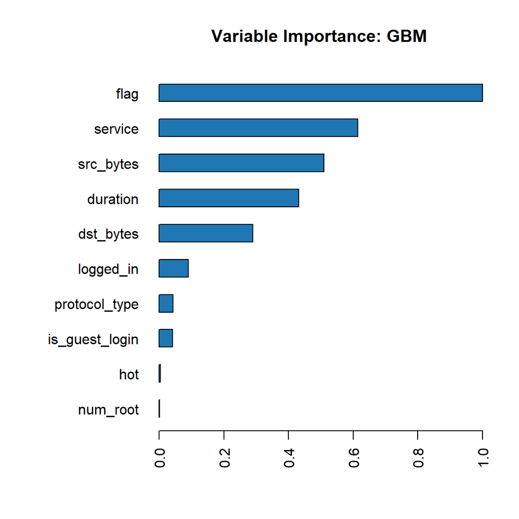

```r
h2o.varimp_plot(gbm, num_of_features = 10)
```

> Roc curve

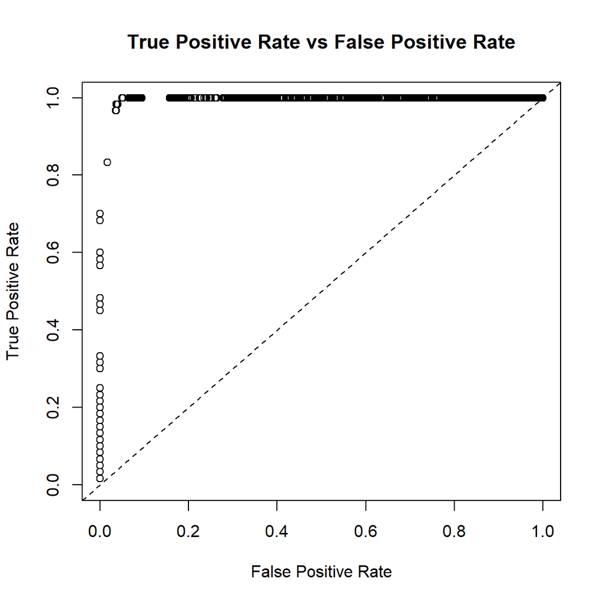

```r
plot(gbm.perf, type="roc")
```

> Partial Dependence

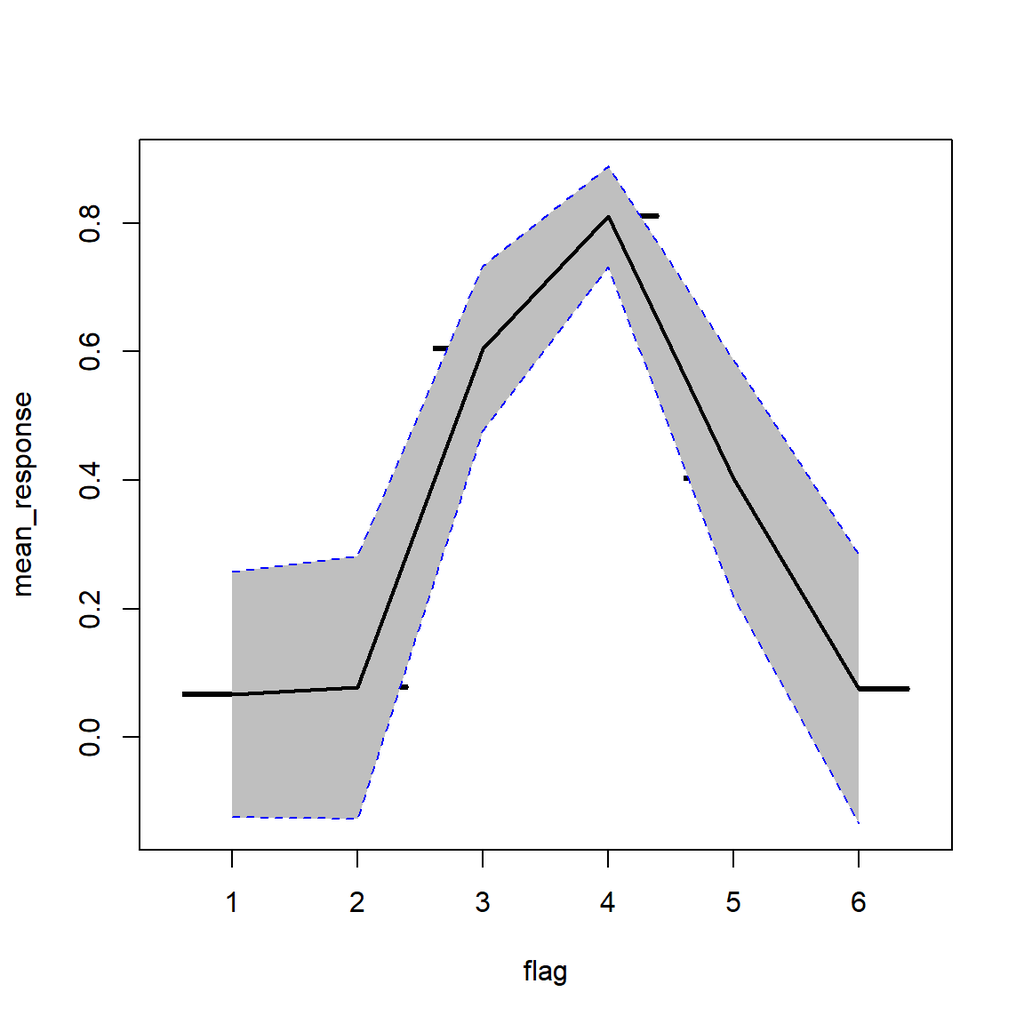

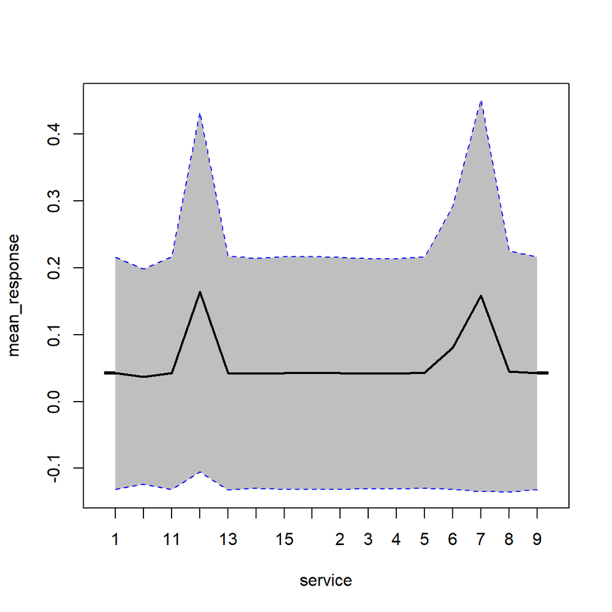

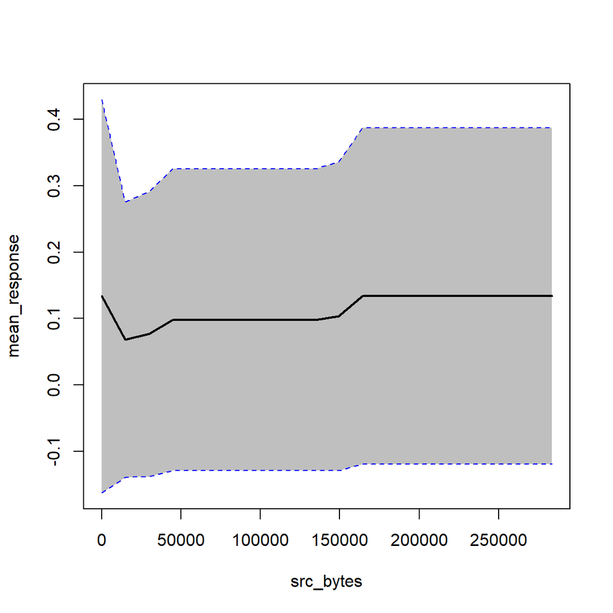

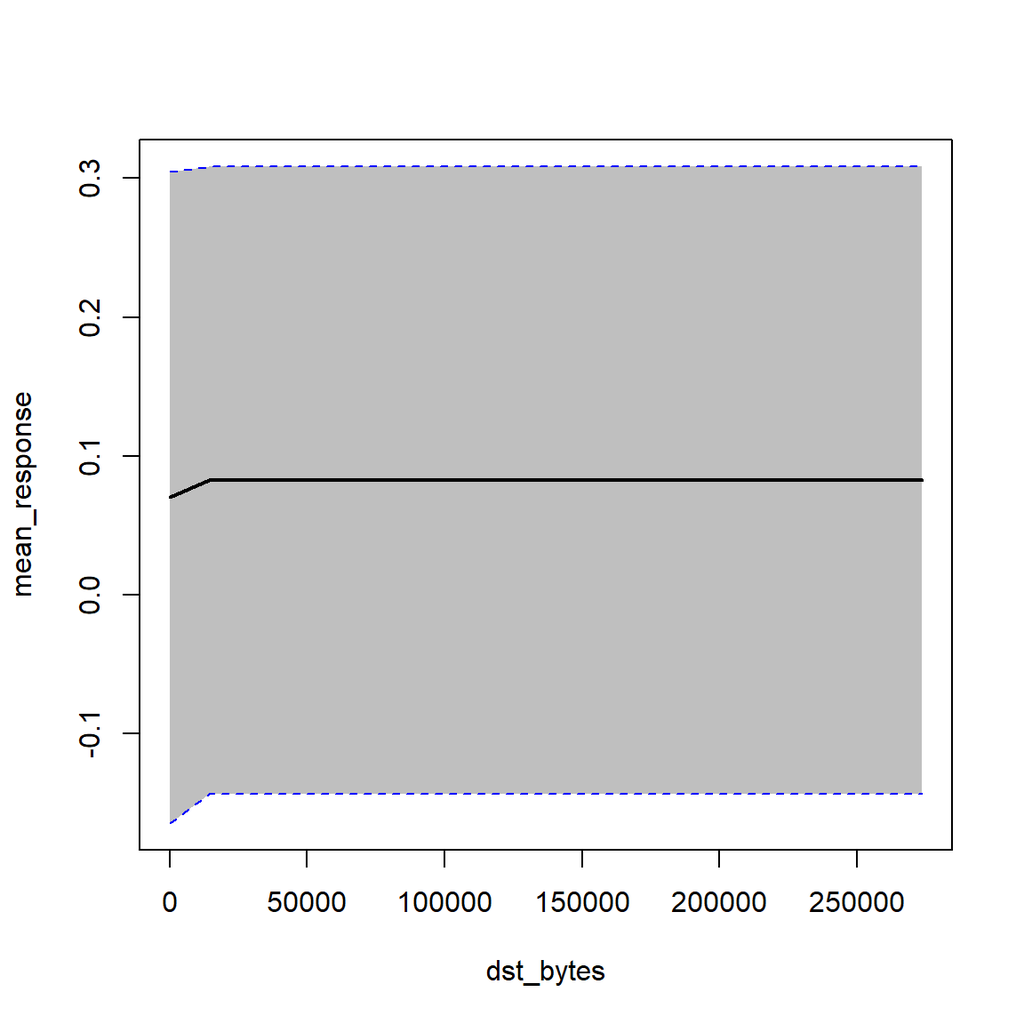

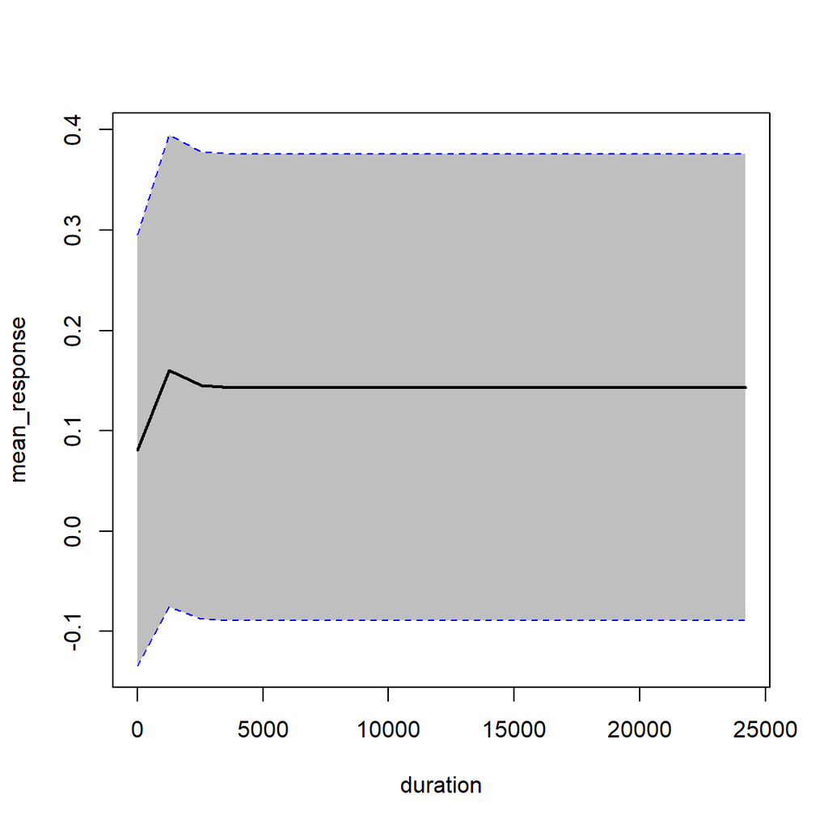

```
## [[1]]
## PartialDependence: Partial Dependence Plot of model final_grid_model_24 on column 'flag'
##   flag mean_response stddev_response std_error_mean_response
## 1    1      0.066624        0.190982                0.003487
## 2    2      0.078207        0.204772                0.003739
## 3    3      0.605327        0.127418                0.002327
## 4    4      0.810230        0.078632                0.001436
## 5    5      0.402282        0.184348                0.003366
## 6    6      0.075438        0.209049                0.003817
##
## [[2]]
## PartialDependence: Partial Dependence Plot of model final_grid_model_24 on column 'service'
##    service mean_response stddev_response std_error_mean_response
## 1        1      0.042287        0.173530                0.003169
## 2       10      0.037244        0.161113                0.002942
```

[output cut: 86 more lines]

```r
h2o.partialPlot(object = gbm, data = network.h2o, cols = c("flag","service", "src_bytes", "dst_bytes", "duration"))
```

> In case we want to use caret package to compare results across models, I transformed data from h2o objects back to R data frames and saved metrics.

```r
# Build "test.set" for metric creation with caret package
pred.frame <- as.data.frame(gbm.preds)
test.frame <- as.data.frame(h2o.test)
test.set <- cbind(pred.frame, obs = test.frame$is_intrusion)
colnames(test.set)[1:3] <- c("pred", "0", "1")

# Confusion matrix full stats
gbm.conf.mat <- confusionMatrix(test.set$pred, test.set$obs, positive = "1")
gbm.sens <- gbm.conf.mat$byClass[1]
gbm.spec <- gbm.conf.mat$byClass[2]

# For precision/recall stats
gbm.prec.rec <- confusionMatrix(test.set$pred, test.set$obs, positive = "1", mode = "prec_recall")
```

# Section 3: Comparison of the Classification Models

## Evaluation of Classification Models on training dataset**

```r
## Logistic
Logistic.train <- c("Logistic",as.numeric(round(logistic.train.cm$byClass[1],2)), as.numeric(round(1-logistic.train.cm$byClass[2],2)) )

## KNN
KNN.train <- c("KNN", as.numeric(round(knn.train.cm$byClass[1],2)), as.numeric(round(1-knn.train.cm$byClass[2],2)))

## Random Forest
RF.train <- c("Random Forest", as.numeric(round(rf.train.cm$byClass[1],2)), as.numeric(round(1-rf.train.cm$byClass[2],2)))


## Gradient boosting machine
gbm.train.auc <- gbm.perf.train@metrics$AUC
gbm.train.sens <- as.numeric(gbm.model@model$cross_validation_metrics_summary["recall",1])
gbm.train.spec <- as.numeric(gbm.model@model$cross_validation_metrics_summary["specificity",1])



compare.table.train <- data.frame("Model"= c("Logistic","KNN", "GBM", "RF"),"True_Positive_Rate"= c(as.numeric(round(logistic.train.cm$byClass[1],4)),as.numeric(round(knn.train.cm$byClass[1],4)),round(gbm.train.sens, 4), as.numeric(round(rf.train.cm$byClass[1],4))), "False_Positive_Rate"=c(as.numeric(round(1-logistic.train.cm$byClass[2],4)),as.numeric(round(1-knn.train.cm$byClass[2],4)),round(1-gbm.train.spec,4), as.numeric(round(1-rf.train.cm$byClass[2],4))))

kable(compare.table.train)
```

| Model | True_Positive_Rate | False_Positive_Rate |
| --- | --- | --- |
| Logistic | 0.9741 | 0.0042 |
| KNN | 0.9736 | 0.0167 |
| GBM | 0.9826 | 0.0240 |
| RF | 0.8708 | 0.0171 |

## Evaluation of Classification Models on test dataset**

```r
## Insert other models below

##Logistic
Logistic.test <- c("Logistic",as.numeric(round(logistic.test.cm$byClass[1],2)), as.numeric(round(1-logistic.test.cm$byClass[2],2)) )

## KNN
KNN.test <- c("KNN", as.numeric(round(knn.test.cm$byClass[1],2)), as.numeric(round(1-knn.test.cm$byClass[2],2)))

##Random Forest
RF.test <- c("Random Forest", as.numeric(round(rf.test.cm$byClass[1],2)), as.numeric(round(1-rf.test.cm$byClass[2],2)))


## Gradient boosting machine
# gbm.perf # Full performance summary of model on test set
# gbm.conf.mat # Caret package summary of confusion matrix stats
# gbm.sens # Sensivity
# gbm.spec # Specificity

compare.table.test <- data.frame("Model"= c("Logistic","KNN", "GBM", "RF"),"True_Positive_Rate"= c(as.numeric(round(logistic.test.cm$byClass[1],4)),as.numeric(round(knn.test.cm$byClass[1],4)),gbm.sens, as.numeric(round(rf.test.cm$byClass[1],4))), "False_Positive_Rate"=c(as.numeric(round(1-logistic.test.cm$byClass[2],4)),as.numeric(round(1-knn.test.cm$byClass[2],4)),1-gbm.spec, as.numeric(round(1-rf.test.cm$byClass[2],4))))
```

## Comparison table

```r
kable(compare.table.test, digits = 4, caption = "Test set comparison on Sensitivity and Specificity (ROC curve measures)")
```

Test set comparison on Sensitivity and Specificity (ROC curve measures)

| Model | True_Positive_Rate | False_Positive_Rate |
| --- | --- | --- |
| Logistic | 0.9610 | 0.0167 |
| KNN | 0.9629 | 0.0333 |
| GBM | 0.9667 | 0.0353 |
| RF | 0.9000 | 0.0204 |

## ROC and AUC plots

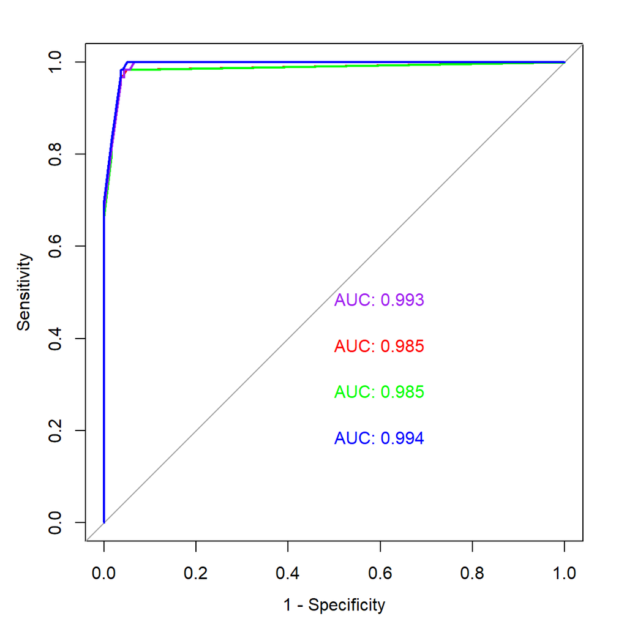

```r
## pRoc library allows plotting ROC curves
## KNN roc, ready to plot
knn.pred.prob <-predict(fit.knn, newdata = network.test, type = "prob") #Predicting class for test data
knn.roc <- roc(network.test$is_intrusion, knn.pred.prob[,"0"]) #roc curve for the model

plot.roc(knn.roc, col="red",print.auc=TRUE, print.auc.y=0.4,legacy.axes=TRUE, legend=TRUE)

##Logistic ROC
logistic.pred.prob <- predict(logistic.fit, network.test, type= "prob")
logistic.roc <- roc(network.test$is_intrusion, logistic.pred.prob[,"1"])
plot.roc(logistic.roc, add=TRUE, col="green",print.auc=TRUE, print.auc.y=0.3,legacy.axes=TRUE, legend=TRUE)

##Random Forest
ypred.rfroc = predict(rf.network,newdata=network.test, type = "Prob")
rf.roc <- roc(intrusion_test, ypred.rfroc[,"1"])
plot.roc(rf.roc,print.auc = TRUE, print.auc.y=0.5, legacy.axis=TRUE,legend=TRUE, add=TRUE, col="Purple")

# gbm roc object prepared above, ready to plot
gbm.roc <- roc( response = test.set$obs , predictor = test.set$`1` )
gbm.auc <- auc(gbm.roc)
plot.roc(gbm.roc, add=TRUE, col="blue",print.auc=TRUE, print.auc.y=0.2,legacy.axes=TRUE, legend=TRUE)
```

- The color scheme is as follows:
- RF = PURPLE
- KNN = RED
- Logistic = GREEN
- GBM = BLUE

# Section 4: Findings

**Summary and Conclusion**

> We find that several models perform well. The KNN, Logistic and GBM models each have similar performance on the test set. Further, the AUC measures are all only marginally different.

> We believe the logistic model and GBM have the most promise. RF performed worse on Sensitivity. Such false negatives can be especially costly in this setting, and so this model should not be used. KNN, meanwhile, is computationally expensive. Since it is not a parametric model, it must search through the dataset each time it classifies a point. This can take a long time with a large dataset, which is detrimental for the purposes of real-time execution.

> The logistic model’s strength is in its simplicity and interpretability. If the bank is concerned with identifying KNOWN attack vectors, the logistic model can provide a straightforward way to update and maintain a model that readily identifies known attacks.

> The GBM is less interpretable. It provides added depth, however, including model tuning and maximized metric options. This model may be better suited to identifying anomalous activity (unknown attack vectors). This may favor the GBM overall if one model must be used. There is a possibility more than one model can be useful when it comes to both logging historic data with **known** attacks and evaluating new requests in real time for anomalies. Th best systems will be able to identify known attacks with extremely high precision and do so very quickly, but also give probabilistic predictions for anomalous activity that a human analyst can furhter assess.